# PML Assignment

Johnny Course

22/03/2015

```r
set.seed(123)
library(caret)
library(tree)
library(rattle)
library(randomForest)
```

# Introduction

We will build a predictive model to determine wheterh or not a specific form of exercise is done correctly using only data obtained from various accelerometers.

# Data sources

The data was downloaded from,

- https://d396qusza40orc.cloudfront.net/predmachlearn/pml-training.csv
- https://d396qusza40orc.cloudfront.net/predmachlearn/pml-testing.csv

And was originally sourced from http://groupware.les.inf.puc-rio.br/har

```r
dataTraining <- read.csv("/tmp/pml-training.csv")
dataTesting  <- read.csv("/tmp/pml-testing.csv")
c(
  dim(dataTraining),                # rows, columns
  sum(complete.cases(dataTraining)) # complete rows
  )
```

```
## [1] 19622   160   406
```

# Selection and preparation

Many of the variables are also derived (min, max, avg, etc) or irrelevant ones. We filter these out and create a list of raw measurements for the inputs.

```r
inputs <- c(
"accel_arm_x",
"accel_arm_y",
"accel_arm_z",
"accel_belt_x",
"accel_belt_y",
"accel_belt_z",
"accel_dumbbell_x",
"accel_dumbbell_y",
"accel_dumbbell_z",
"accel_forearm_x",
"accel_forearm_y",
"accel_forearm_z",
"gyros_arm_x",
"gyros_arm_y",
"gyros_arm_z",
"gyros_belt_x",
"gyros_belt_y",
"gyros_belt_z",
"gyros_dumbbell_x",
"gyros_dumbbell_y",
"gyros_dumbbell_z",
"gyros_forearm_x",
"gyros_forearm_y",
"gyros_forearm_z",
"magnet_arm_x",
"magnet_arm_y",
"magnet_arm_z",
"magnet_belt_x",
"magnet_belt_y",
"magnet_belt_z",
"magnet_dumbbell_x",
"magnet_dumbbell_y",
"magnet_dumbbell_z",
"magnet_forearm_x",
"magnet_forearm_y",
"magnet_forearm_z",
"pitch_arm",
"pitch_belt",
"pitch_dumbbell",
"pitch_forearm",
"roll_arm",
"roll_belt",
"roll_dumbbell",
"roll_forearm",
"total_accel_arm",
"total_accel_belt",
"total_accel_dumbbell",
"total_accel_forearm",
"yaw_arm",
"yaw_belt",
"yaw_dumbbell",
"yaw_forearm"
)
```

We add the ‘classe’ classification field and subset the data accordingly

```r
selectedDataTraining <- dataTraining[,c(inputs, "classe")]
c(
  dim(selectedDataTraining),                # rows, columns
  sum(complete.cases(selectedDataTraining)) # complete rows
  )
```

```
## [1] 19622    53 19622
```

This gives us 19622 cases, all of which are complete and that makes this a viable dataset.

To perform initial correlation analysis we require numeric values, which classe is not. We will create a subset of selectedTrainingData that holds only numeric values, analyze it for strongly correlated variables and visualize these with a heatmap.

```r
numericSelectedDataTraining <- selectedDataTraining[,names(selectedDataTraining) != "classe"]
correlationsTraining        <- cor(numericSelectedDataTraining)
```

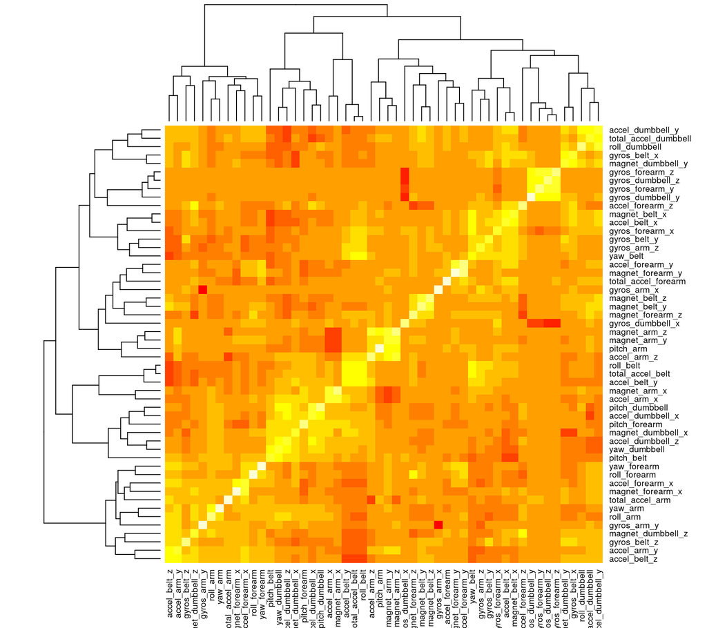

```r
heatmap(correlationsTraining)
```

The heatmap does not appear to show many strong correlations. To identify the ones that are strongly correlated (and not with themselves) we we select all 90%+ values,

```r
cutoff <- .9
highCorrelations <- correlationsTraining[
  (correlationsTraining < -cutoff | correlationsTraining > cutoff) & correlationsTraining != 1.0
  ]
highCorrelations
```

```
##  [1] -0.9657334 -0.9333854  0.9248983  0.9278069 -0.9333854 -0.9920085
##  [7] -0.9749317 -0.9181821 -0.9181821 -0.9789507 -0.9144764 -0.9789507
## [13]  0.9330422 -0.9144764  0.9330422 -0.9657334  0.9248983 -0.9920085
## [19]  0.9809241  0.9278069 -0.9749317  0.9809241
```

We will remove these from the dataset before continuing

```r
excessValues         <- findCorrelation(correlationsTraining, cutoff = cutoff)
filteredDataTraining <- selectedDataTraining[-excessValues]

dim(filteredDataTraining)
```

```
## [1] 19622    46
```

We partition this filtered data to create our local training and testing sets

```r
trainingPartition <- createDataPartition(
  y=filteredDataTraining$classe,
  p=.8,
  list=F
  )
finalTraining <- filteredDataTraining[trainingPartition, ]
finalTesting  <- filteredDataTraining[-trainingPartition, ]
```

# Analysis

Now that we have prepared a workable dataset we can fit a regression tree using binary recursive partitioning.

```r
trainingTree <- tree(
  data=finalTraining,
  method="recursive.partition",
  classe~.
  )

summary(trainingTree)
```

```
##
## Classification tree:
## tree(formula = classe ~ ., data = finalTraining, method = "recursive.partition")
## Variables actually used in tree construction:
##  [1] "pitch_forearm"     "magnet_belt_y"     "accel_forearm_z"
##  [4] "magnet_dumbbell_y" "roll_forearm"      "magnet_dumbbell_z"
##  [7] "pitch_belt"        "yaw_belt"          "accel_forearm_x"
## [10] "accel_dumbbell_y"  "yaw_dumbbell"      "magnet_arm_x"
## [13] "accel_dumbbell_z"  "gyros_belt_z"
## Number of terminal nodes:  21
## Residual mean deviance:  1.652 = 25900 / 15680
## Misclassification error rate: 0.3209 = 5038 / 15699
```

```r
trainedModel <- train(
  classe ~ .,
  data=finalTraining,
  method="rpart"
  )
```

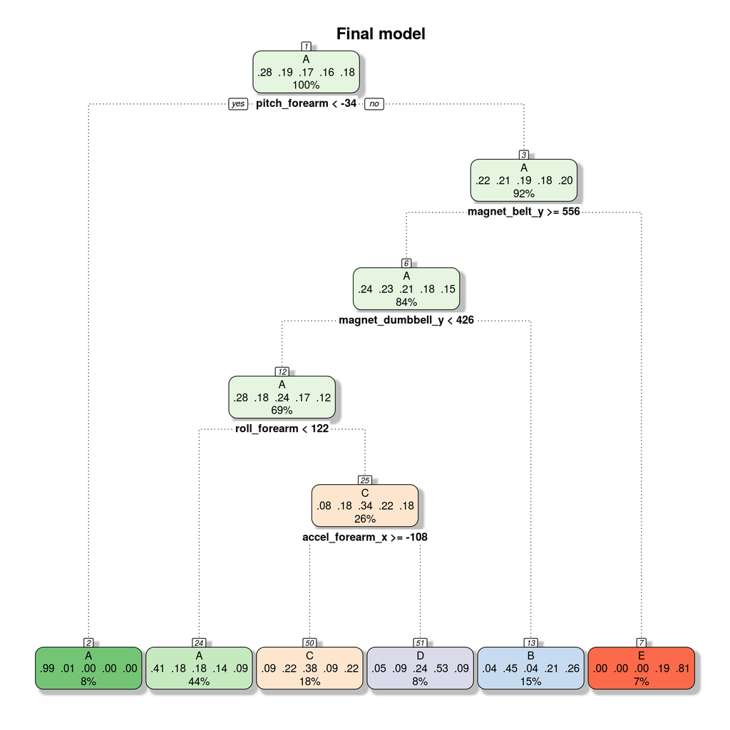

```r
fancyRpartPlot(
  trainedModel$finalModel,
  main="Final model",
  sub=""
  )
```

Accuracy for this model is,

```r
max(trainedModel$results$Accuracy) * 100
```

```
## [1] 51.94342
```

The accuracy for this model is pretty dismal at 52% meaning its predictive capability is only marginally better than flipping a coin. We will use a different approach with Random Forests.

```r
controlModel <- trainControl(
  method="cv",
  number=4
  )
```

```r
trainedForestModel <- train(
  classe~.,
  data=finalTraining,
  method="rf", # random forest as opposed to rpart
  trControl=controlModel
  )
```

Summary

```r
trainedForestModel
```

```
## Random Forest
##
## 15699 samples
##    45 predictors
##     5 classes: 'A', 'B', 'C', 'D', 'E'
##
## No pre-processing
## Resampling: Cross-Validated (4 fold)
##
## Summary of sample sizes: 11772, 11775, 11776, 11774
##
## Resampling results across tuning parameters:
##
##   mtry  Accuracy   Kappa      Accuracy SD  Kappa SD
##    2    0.9898724  0.9871871  0.001442701  0.001825033
##   23    0.9912098  0.9888803  0.001630222  0.002062100
##   45    0.9844581  0.9803396  0.003867348  0.004892881
##
## Accuracy was used to select the optimal model using  the largest value.
## The final value used for the model was mtry = 23.
```

Accuracy for this model is,

```r
max(trainedForestModel$results$Accuracy) * 100
```

```
## [1] 99.12098
```

This model gives us a huge increase in accuracy at 99.1%.

# Cross-validation

We will now use this model to make predictions against the data we partitioned out for testing,

```r
testingData <- finalTesting # making a minor modification to add the prediction results

prediction <- predict(trainedForestModel, testingData)
testingData$correct <- prediction == testingData$classe
table(prediction, testingData$classe)
```

```
##
## prediction    A    B    C    D    E
##          A 1115    2    0    0    0
##          B    1  756    3    0    0
##          C    0    1  681    6    0
##          D    0    0    0  637    0
##          E    0    0    0    0  721
```